# TP4 — Principal Component Analysis (PCA) part 1

Basic PCA concepts - Hepatitis C dataset

Massimo Andreatta

2026-07-23

> **How to use this notebook.** You do **not** need any programming experience. Read each short explanation, then press the green *play* button (▶) at the top-right of each grey *code chunk* to run it. Look at the output, and answer the **Questions** in the green boxes (write your answers in plain text under each one). The goal is to *understand the data and the method*, not to memorise code.

# INTRODUCTION TO PRINCIPAL COMPONENT ANALYSIS

## The problem: too many variables, too few dimensions

In medicine we routinely measure many things about each patient — blood tests, vital signs, imaging findings. When there are six, ten, or fifty measurements per patient, it becomes impossible to *see* the data: you cannot draw a 50-dimensional scatter plot. Yet a lot of information in those measurements is **redundant** — for example, two liver enzymes that always rise together carry roughly the same information.

**Principal Component Analysis (PCA)** exploits this redundancy to compress many variables into a small number of new variables — the **principal components** — that still capture most of the interesting variation. Think of it as finding the best angle from which to photograph a 3-D sculpture: you lose one dimension, but if you choose the right angle you preserve the important structure.

## What PCA actually does — step by step

Imagine you measure two things for each person: height and weight. You could plot every person as a point in a 2-D scatter plot. Because taller people tend to weigh more, the two measurements will display a positive **correlation** in the scatterplot.

PCA asks: *what single axis through this cloud of points captures the most spread?* That axis is **PC1**. A second axis, perpendicular to the first, captures the next most spread — that is **PC2**. Together they form a new coordinate system that is rotated relative to the original axes.

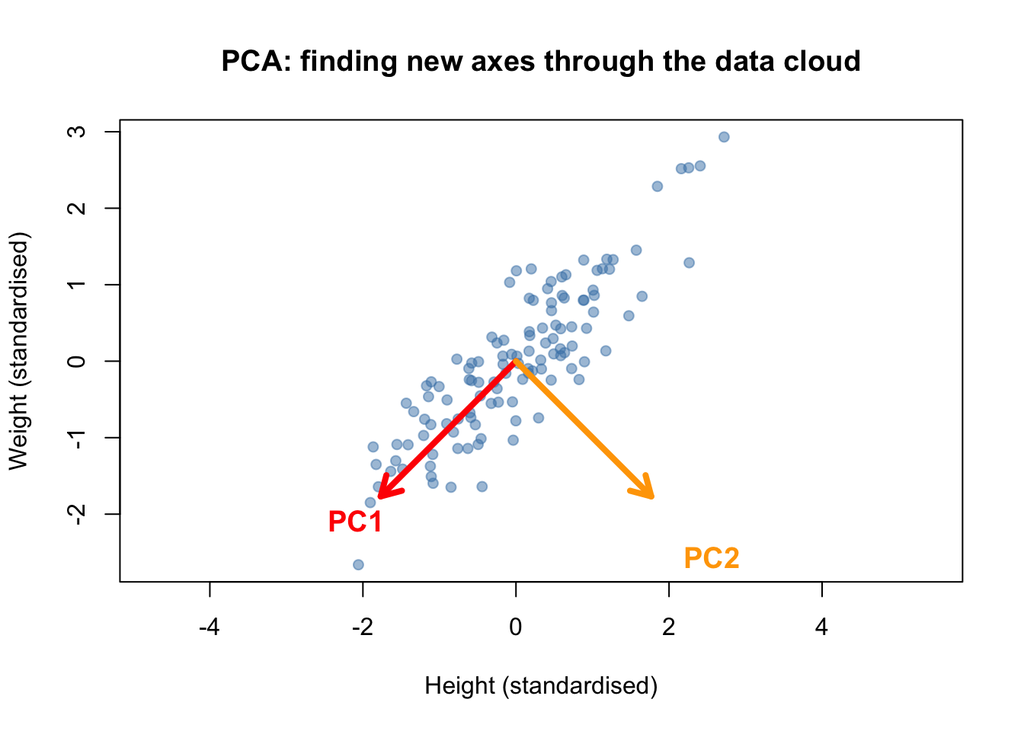

The red arrow (PC1) points in the direction of greatest spread — people are most spread out along this axis. The orange arrow (PC2) is perpendicular to PC1 and captures the remaining spread.

> **Question 0.1.** In the plot above, the data cloud is elongated diagonally. What does the elongation tell you about the relationship between height and weight?

> **Question 0.2.** If height and weight were completely *uncorrelated*, how would the cloud of points look like?

> **Question 0.3.** If height and weight were completely *uncorrelated*, what would the PC1 and PC2 arrows look like? Would PCA still be useful for dimensionality reduction in that case?

## How to read a PCA plot

After running PCA, each patient is represented as a single point in the new coordinate system. This “PCA plot” is the central output of PCA. Here is how to interpret it:

- **Proximity = similarity.** Two patients whose points are close together have similar values across most of the measured variables.
- **Distance = difference.** A patient at the far right of the plot and one at the far left differ substantially in the variables that drive PC1.
- **Cluster = group.** If several patients form a tight cloud, they share a biological profile — they may be a clinically coherent subgroup.
- **Outlier = unusual.** A point far from all others has an unusual combination of measurements. It is worth investigating whether this reflects a true biological extreme or a data-quality issue (measurement error, mislabelling).
- **Direction is meaningful.** Once we know which variables drive each PC (from the *loadings* — a tool we will introduce in TP5), we can say *why* a patient sits in a particular region of the plot.

## Key vocabulary

| Term | Plain-language meaning |
| --- | --- |
| **Principal component (PC)** | A new axis through the data; a weighted combination of the original variables |
| **Score** | A patient’s coordinate on a PC — where they sit along that axis |
| **Loading** | How much each original variable contributes to a PC (its “weight” on that axis) |
| **Variance explained** | The % of total spread captured by a PC — larger means more informative |
| **Scree plot** | A bar chart of variance explained by each PC, used to decide how many to keep |

# THE DATASET: HEPATITIS C BLOOD PANEL

Each row is one person who had a blood sample analysed. The data come from the [UCI HCV dataset](https://archive.ics.uci.edu/dataset/571/hcv+data), containing healthy **blood donors** and patients with hepatitis C at increasing stages of liver damage (**Hepatitis → Fibrosis → Cirrhosis**).

The ten numeric columns are routine **laboratory tests**:

| Code | Lab test | What it reflects |
| --- | --- | --- |
| ALB | Albumin | Liver synthetic function (falls when liver fails) |
| ALP | Alkaline phosphatase | Bile ducts / liver |
| ALT | Alanine aminotransferase | Liver-cell damage (rises with inflammation) |
| AST | Aspartate aminotransferase | Liver-cell damage |
| BIL | Bilirubin | Liver clearance (rises in jaundice) |
| CHE | Cholinesterase | Liver synthetic function (falls when liver fails) |
| CHOL | Cholesterol | Liver / metabolism |
| CREA | Creatinine | Kidney function |
| GGT | Gamma-glutamyl transferase | Bile ducts / liver |
| PROT | Total protein | Overall protein level |

`Category` is the diagnosis and `Sex` is m/f.

This dataset is particularly well suited to PCA: the ten tests are not independent (several measure related aspects of liver function), and disease severity follows an ordered progression — an ideal setting for PCA to reveal biological structure.

## Load the data

```r
hcv <- read.csv("../data/hcvdat0.csv", row.names = 1)
```

Let’s look at the first few rows of the dataset, using the `head()` command:

```r
head(hcv)
```

```
##        Category Age Sex  ALB  ALP  ALT  AST  BIL   CHE CHOL CREA  GGT PROT
## 1 0=Blood Donor  32   m 38.5 52.5  7.7 22.1  7.5  6.93 3.23  106 12.1 69.0
## 2 0=Blood Donor  32   m 38.5 70.3 18.0 24.7  3.9 11.17 4.80   74 15.6 76.5
## 3 0=Blood Donor  32   m 46.9 74.7 36.2 52.6  6.1  8.84 5.20   86 33.2 79.3
## 4 0=Blood Donor  32   m 43.2 52.0 30.6 22.6 18.9  7.33 4.74   80 33.8 75.7
## 5 0=Blood Donor  32   m 39.2 74.1 32.6 24.8  9.6  9.15 4.32   76 29.9 68.7
## 6 0=Blood Donor  32   m 41.6 43.3 18.5 19.7 12.3  9.92 6.05  111 91.0 74.0
```

For the following analyses, we create a more readable diagnosis label ordered by severity

```r
hcv$Group <- factor(gsub("^0.*", "Donor", hcv$Category),
                    levels = c("Donor", "1=Hepatitis", "2=Fibrosis", "3=Cirrhosis"),
                    labels = c("Donor", "Hepatitis", "Fibrosis", "Cirrhosis"))

labs <- c("ALB","ALP","ALT","AST","BIL","CHE","CHOL","CREA","GGT","PROT")

# Colour palette: blue (healthy) → red (severe)
grp_cols <- c(Donor     = "#2166AC",
              Hepatitis = "#92C5DE",
              Fibrosis  = "#F4A582",
              Cirrhosis = "#B2182B")
```

# 1 — Meet the data

## Size, groups, and missing values

```r
dim(hcv)
```

```
## [1] 615  14
```

```r
table(hcv$Group)
```

```
##
##     Donor Hepatitis  Fibrosis Cirrhosis
##       540        24        21        30
```

```r
colSums(is.na(hcv[, labs]))
```

```
##  ALB  ALP  ALT  AST  BIL  CHE CHOL CREA  GGT PROT
##    1   18    1    0    0    0   10    0    0    1
```

```r
missing <- sum(!complete.cases(hcv[, labs]))

cat("Patients with at least one missing lab value:", missing, "\n")
```

```
## Patients with at least one missing lab value: 26
```

Some patients are missing one or more lab values. PCA requires complete data, so we keep only patients with all ten measurements. We lose a small fraction of the cohort but keep the analysis straightforward.

```r
hcv_c <- hcv[complete.cases(hcv[, labs]), ]
cat("Patients retained:", nrow(hcv_c), "\n")
```

```
## Patients retained: 589
```

```r
table(hcv_c$Group)
```

```
##
##     Donor Hepatitis  Fibrosis Cirrhosis
##       533        20        12        24
```

> **Question 1.1.** Have a look at the `hcv` table. How many patients are present in this object? what variables are available, besides the lab test measurements?

> **Question 1.2.** How many patients remain after removing incomplete cases? Which disease group loses the most patients to missing values — and can you guess why certain tests might be missing more often than others?

## Distributions and skewness

Right-skewed variables distort PCA — extreme values in a few patients drag the axes. Let us check all ten tests.

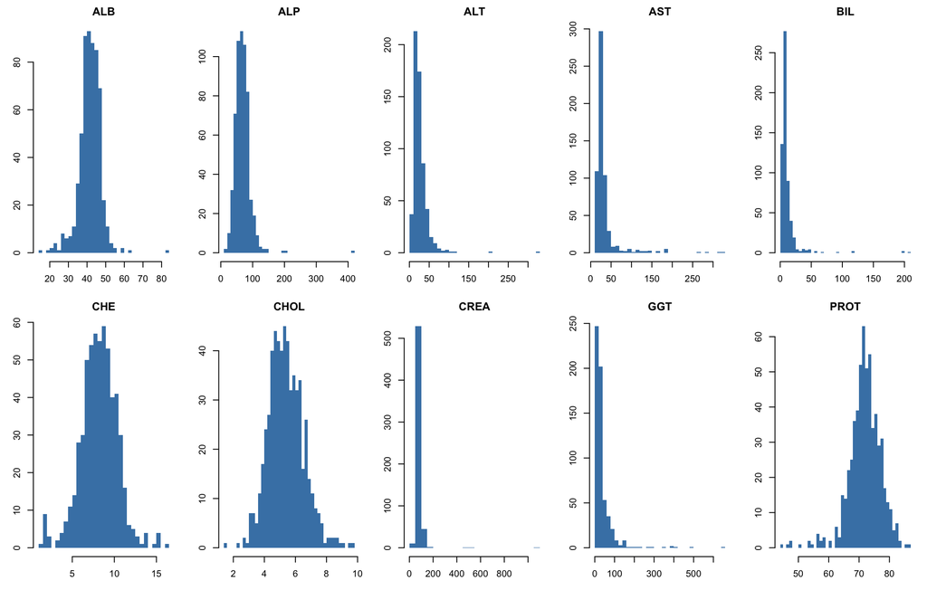

```r
par(mfrow = c(2, 5), mar = c(3, 3, 2, 1))
for (v in labs) {
  hist(hcv_c[[v]], breaks = 35, col = "steelblue", border = NA,
       main = v, xlab = "")
}
```

Several test measurments are heavily right-skewed — i.e. the majority of patients cluster at low values but a few reach extreme highs. We apply a log-transformation to these before running PCA.

```r
hcv_c$log_ALT <- log(hcv_c$ALT)
hcv_c$log_AST <- log(hcv_c$AST)
hcv_c$log_BIL <- log(hcv_c$BIL)
hcv_c$log_GGT <- log(hcv_c$GGT)

labs_clean <- c("ALB","ALP","log_ALT","log_AST","log_BIL",
                "CHE","CHOL","CREA","log_GGT","PROT")
```

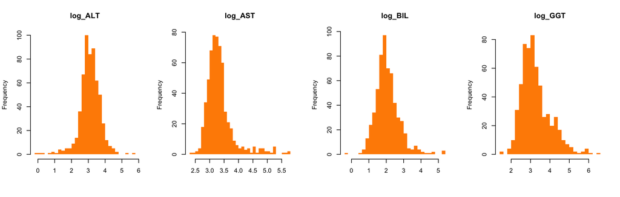

```r
par(mfrow = c(1, 4))
for (v in c("log_ALT","log_AST","log_BIL","log_GGT")) {
  hist(hcv_c[[v]], breaks = 35, col = "darkorange", border = NA,
       main = v, xlab = "")
}
```

```r
par(mfrow = c(1, 1))
```

> **Question 1.3.** Which of the ten tests are most heavily right-skewed in the original scale? Why might patients with cirrhosis drive the extreme values in ALT, AST and GGT specifically — what do these tests measure?

> **Question 1.4.** After log-transformation, do the distributions of ALT, AST, BIL and GGT look more symmetric? Why does a more symmetric distribution help PCA produce interpretable components?

## Correlation between variables — why PCA is useful

Before running PCA it is instructive to look at **how the ten lab tests relate to each other**. If variables were completely independent, there would be little to compress. If they are correlated, PCA can capture that shared structure in fewer dimensions.

```r
cor_mat <- cor(hcv_c[, labs_clean], use = "complete.obs")
round(cor_mat, 2)
```

```
##           ALB   ALP log_ALT log_AST log_BIL   CHE  CHOL  CREA log_GGT  PROT
## ALB      1.00 -0.15    0.23   -0.15   -0.01  0.36  0.21  0.00   -0.06  0.57
## ALP     -0.15  1.00    0.10    0.08    0.00  0.03  0.13  0.15    0.29 -0.06
## log_ALT  0.23  0.10    1.00    0.15   -0.15  0.39  0.27 -0.16    0.20  0.15
## log_AST -0.15  0.08    0.15    1.00    0.41 -0.11 -0.16  0.00    0.53  0.05
## log_BIL -0.01  0.00   -0.15    0.41    1.00 -0.23 -0.19  0.06    0.24  0.07
## CHE      0.36  0.03    0.39   -0.11   -0.23  1.00  0.43 -0.01    0.05  0.31
## CHOL     0.21  0.13    0.27   -0.16   -0.19  0.43  1.00 -0.05    0.08  0.25
## CREA     0.00  0.15   -0.16    0.00    0.06 -0.01 -0.05  1.00    0.18 -0.03
## log_GGT -0.06  0.29    0.20    0.53    0.24  0.05  0.08  0.18    1.00  0.05
## PROT     0.57 -0.06    0.15    0.05    0.07  0.31  0.25 -0.03    0.05  1.00
```

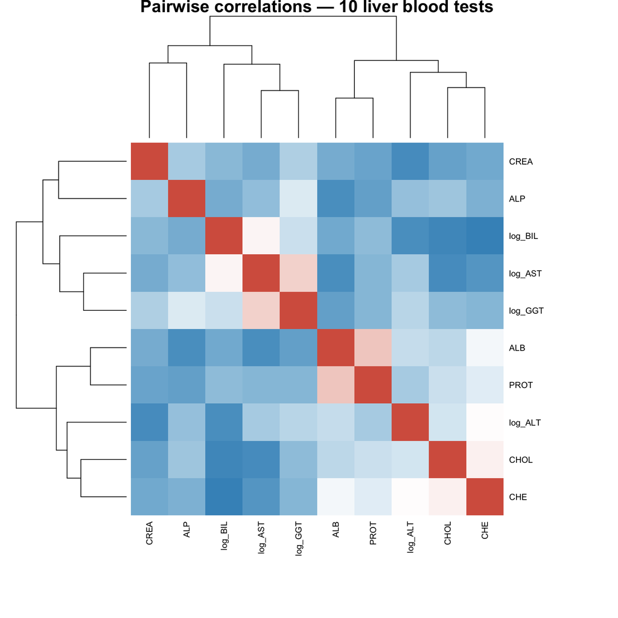

```r
col_heat <- colorRampPalette(c("#4393c3", "white", "#d6604d"))(100)
heatmap(cor_mat,
        col    = col_heat,
        scale  = "none",
        symm   = TRUE,
        margins = c(9, 9),
        cexRow = 0.9, cexCol = 0.9,
        main   = "Pairwise correlations — 10 liver blood tests")
```

> **Question 1.5.** Which pairs of variables shows the strongest positive or negative correlation? Does the direction (positive or negative) make biological sense? think for example of tests that measure similar physiological functions.

> **Question 1.6.** Variables that are strongly correlated carry **redundant** information — knowing one tells you a lot about the other. If two variables were perfectly correlated (r = 1), how many independent dimensions of information would they represent together? Why does this motivate PCA as a way to reduce the number of dimensions?

# 2 — Why standardise before PCA?

PCA finds directions of **maximum variance**. A variable measured in large numbers (e.g. creatinine in µmol/L) would dominate the result over one measured in small numbers (e.g. cholesterol in mmol/L), even if both carry equal biological information.

We will calculate standard deviation (`sd`) for each of the lab measurements:

```r
round(apply(hcv_c[, labs_clean], 2, sd, na.rm = TRUE), 3)
```

```
##     ALB     ALP log_ALT log_AST log_BIL     CHE    CHOL    CREA log_GGT    PROT
##   5.762  25.921   0.619   0.488   0.687   2.191   1.129  50.697   0.753   5.349
```

Scaling ensures that all variables have a mean = 0 and standard deviation = 1

```r
X <- scale(hcv_c[, labs_clean])
```

Check that this is indeed the case

```r
means <- round(apply(X, 2, mean), 3)
means   # should be all ≈ 0
```

```
##     ALB     ALP log_ALT log_AST log_BIL     CHE    CHOL    CREA log_GGT    PROT
##       0       0       0       0       0       0       0       0       0       0
```

```r
standard_deviations <- round(apply(X, 2, sd),   3)
standard_deviations  # should be all = 1
```

```
##     ALB     ALP log_ALT log_AST log_BIL     CHE    CHOL    CREA log_GGT    PROT
##       1       1       1       1       1       1       1       1       1       1
```

> **Question 2.1.** Before scaling, which variable has the largest standard deviation? If we ran PCA without standardising, which variable would likely dominate PC1 — and would that be biologically meaningful?

> **Question 2.2.** We already log-transformed four tests. Does log- transformation change the need for standardisation, or are both steps necessary for different reasons?

> **Question 2.3.** After standardisation, what does a score of +2 for a patient on the ALT column mean? How does this patient’s ALT compare to the average for the cohort?

# 3 — Running PCA

## Computing the principal components

`prcomp()` rotates the data so that the first axis (**PC1**) captures as much variance as possible, the second (**PC2**) captures as much of the *remaining* variance as possible, and so on. The total number of PCs equals the number of input variables (here, ten).

```r
pca <- prcomp(X, scale. = FALSE)   # already scaled above
summary(pca)
```

```
## Importance of components:
##                           PC1    PC2    PC3    PC4     PC5     PC6     PC7
## Standard deviation     1.5336 1.3880 1.1683 1.0637 0.87535 0.82286 0.74610
## Proportion of Variance 0.2352 0.1926 0.1365 0.1132 0.07662 0.06771 0.05567
## Cumulative Proportion  0.2352 0.4279 0.5643 0.6775 0.75411 0.82182 0.87749
##                            PC8     PC9    PC10
## Standard deviation     0.70360 0.64442 0.56108
## Proportion of Variance 0.04951 0.04153 0.03148
## Cumulative Proportion  0.92699 0.96852 1.00000
```

The `summary()` shows three rows for each PC: - **Standard deviation**: the spread of patient scores along that axis. - **Proportion of Variance**: the fraction of total variance captured by this PC — this is what we usually call “variance explained”. - **Cumulative Proportion**: the total fraction captured by all PCs up to and including this one.

# 4 — The PCA plot

Each patient becomes a single point in PCA space. Points close together are clinically similar across the ten measurements; points far apart differ substantially. Crucially, the PCA was computed **without any knowledge of the diagnosis** and is only defined by the blood test values.

We can then colour the PCA plot by disease group to see whether PCA — which had no knowledge of the diagnosis — recovers the biological structure.

```r
scores <- as.data.frame(pca$x)
scores$Group <- hcv_c$Group
col_pts <- grp_cols[as.character(scores$Group)]
```

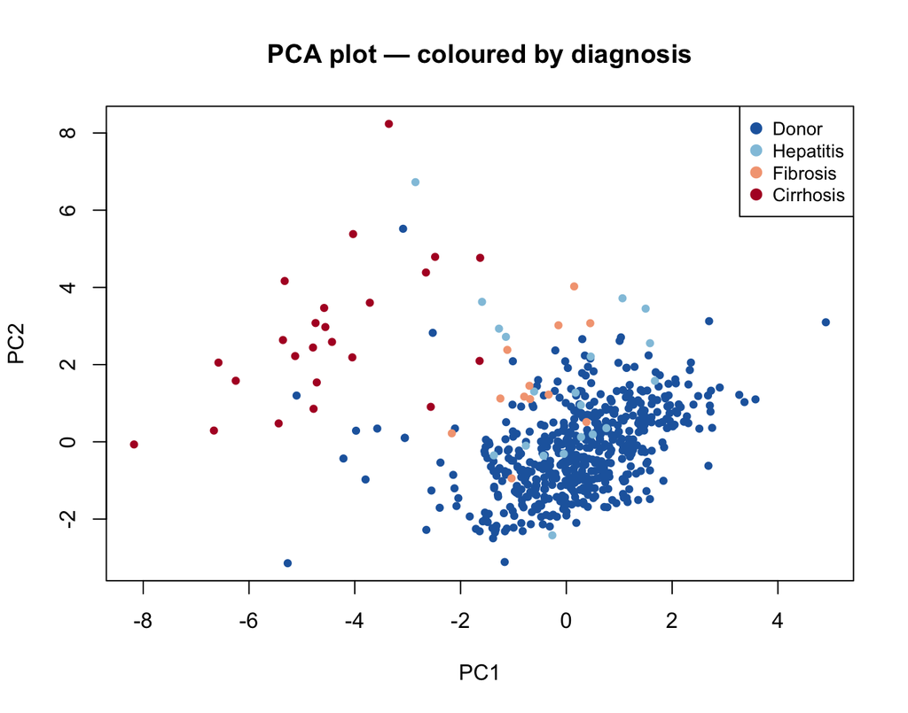

```r
plot(scores$PC1, scores$PC2,
     col = col_pts, pch = 19, cex = 0.7,
     xlab = "PC1",
     ylab = "PC2",
     main = "PCA plot — coloured by diagnosis")
legend("topright", legend = names(grp_cols), col = grp_cols,
       pch = 19, cex = 0.85, pt.cex = 1.1)
```

> **Question 4.1.** Do the four diagnosis groups separate along PC1, PC2, or both? Is the ordering of the groups along PC1 consistent with the biological progression of liver disease (Donor → Hepatitis → Fibrosis → Cirrhosis)?

> **Question 4.2.** Are the Donor and Cirrhosis groups well separated, or do they overlap substantially? What about Hepatitis and Fibrosis — are they easier or harder to distinguish? Does this reflect the clinical reality of diagnosing intermediate stages of liver disease?

> **Question 4.3.** Without knowing the diagnosis labels in advance, could you have guessed that healthy donors and cirrhosis patients sit on opposite sides of PC1? What feature of the PCA plot gives you a clue? (Hint: think about the spread and density of the clouds.)

## Mapping individual lab tests onto the PCA

We can colour the same patient cloud by the value of a specific lab test to reveal which measurements explain the position of patients along each PC axis.

```r
map_color <- function(x, n = 100) {
  pal <- colorRampPalette(c("blue", "white", "red"))(n)
  idx <- cut(x, breaks = n, labels = FALSE, include.lowest = TRUE)
  pal[idx]
}
```

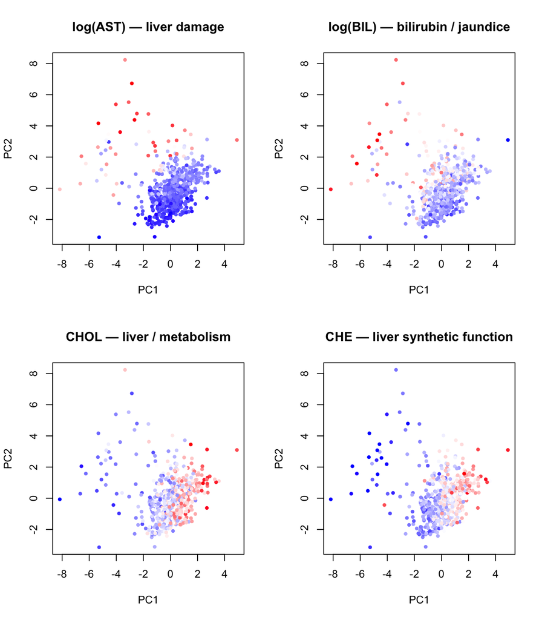

```r
par(mfrow = c(2, 2))

plot(scores$PC1, scores$PC2, pch = 19, cex = 0.6,
     col = map_color(hcv_c$log_AST),
     main = "log(AST) — liver damage",
     xlab = "PC1", ylab = "PC2")

plot(scores$PC1, scores$PC2, pch = 19, cex = 0.6,
     col = map_color(hcv_c$log_BIL),
     main = "log(BIL) — bilirubin / jaundice",
     xlab = "PC1", ylab = "PC2")

plot(scores$PC1, scores$PC2, pch = 19, cex = 0.6,
     col = map_color(hcv_c$CHOL),
     main = "CHOL — liver / metabolism",
     xlab = "PC1", ylab = "PC2")

plot(scores$PC1, scores$PC2, pch = 19, cex = 0.6,
     col = map_color(hcv_c$CHE),
     main = "CHE — liver synthetic function",
     xlab = "PC1", ylab = "PC2")
```

*In all plots: red = high values, blue = low values.*

> **Question 4.4.** CHOL and CHE **fall** as the liver loses its synthetic function, while AST and BIL **rise** with progressive liver damage (red = high, blue = low). Looking at the colour gradients: on which side of PC1 do patients with *high* CHOL and CHE (red) cluster? Do patients with *high* AST and BIL (red) sit on the *same* side or on the *opposite* side? What does this tell you about the biological meaning of PC1?

> **Question 4.5.** From these colour plots alone, which single tests seem most strongly correlated with position along PC1?

> **Question 4.6.** How could you make the same plots for the other lab test values? are some of these other variables seemingly randomly distributed in the PCA space? what does that mean?

# 5 — How much variance is captured?

## Scree plot

A **scree plot** is a bar chart with one bar per principal component. The height of each bar shows the percentage of total variance that component captures. PC1 always has the tallest bar; the bars then decrease (PCA is defined this way — each PC captures as much of the *remaining* variance as possible).

The name comes from geology: a *scree* is the pile of loose rock fragments at the base of a cliff. In a typical scree plot the bars form a steep cliff followed by a flat rubble zone. We look for the **elbow** — the point where the bars stop dropping sharply and the plot flattens out. PCs beyond the elbow each add very little new information and are often dominated by noise.

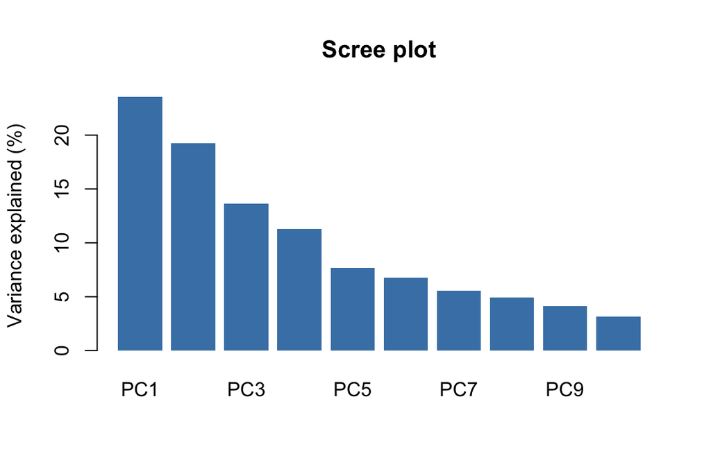

```r
var_exp <- pca$sdev^2 / sum(pca$sdev^2) * 100

par(mfrow = c(1, 1))
barplot(var_exp,
        names.arg = paste0("PC", seq_along(var_exp)),
        col = "steelblue", border = NA,
        ylab = "Variance explained (%)",
        main = "Scree plot")
```

The scree plot tells us how informative each PC is individually. The **cumulative variance plot** below answers a complementary question: *how many PCs do we need to keep to retain a given fraction of the total information?* The dashed line marks 80 % — a common practical threshold.

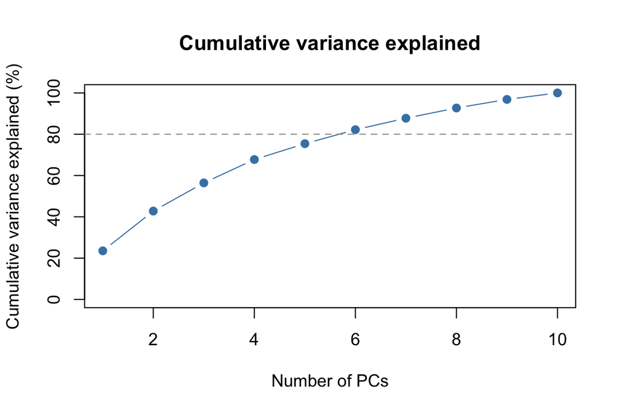

```r
plot(cumsum(var_exp), type = "b", pch = 19, col = "steelblue",
     xlab = "Number of PCs", ylab = "Cumulative variance explained (%)",
     main = "Cumulative variance explained", ylim = c(0, 100))
abline(h = 80, lty = 2, col = "grey60")
```

> **Question 5.1.** How much variance does PC1 explain on its own? Given that we have ten input variables, is it surprising that a single axis can capture such a large fraction? What does this suggest about the redundancy among these liver tests?

> **Question 5.2.** How many PCs would you need to retain to explain at least 80 % of the variance? Is there a clear “elbow” in the scree plot, i.e. a point where adding another PC gives sharply diminishing returns?

> **Question 5.3.** If the scree plot were completely flat (every PC explained exactly 10 % of the variance), what would that tell you about the ten lab tests — are they correlated with one another, or completely independent?

# 6 — Wrap-up

> **Question 6.1 (wrap-up).** In four or five sentences, summarise the journey: How much of the variation in ten lab tests can be captured by just two or three axes? What do those axes represent biologically? Does the disease progression (Donor → Hepatitis → Fibrosis → Cirrhosis) appear as a gradient in PCA space, and which specific tests drive that gradient?